# The epimutacions User’s Guide

Leire Abarrategui, Carles Hernandez-Ferrer, Carlos Ruiz-Arenas and Juan R. Gonzalez

isglobal Bioinformatics Research Group in Epidemiology (BRGE), Barcelona Insitute for Global Health (ISGlobal)  
Faculty of Medical Sciences, Newcastle University, Newcastle-Upon-Tyne, UK  
Autonomous University of Barcelona (UAB)  
Centro Nacional de Análisis Genómico (CNAG-CRG), Center for Genomic, Regulation  
Barcelona Institute of Science and Technology (BIST), Barcelona, Catalonia, Spain  
Centro de Investigación Biomédica en Red de Enfermedades Raras (CIBERER), Barcelona, Spain  
Universitat Pompeu Fabra (UPF), Barcelona, Spain  
uab Department of Mathematics, Autonomous University of Barcelona (UAB)

leire.abarrategui-martinez@newcastle.ac.uk  
carles.hernandez@cnag.crg.eu  
carlos.ruiza@upf.edu  
juanr.gonzalez@isglobal.org

2021-09-27

#### Abstract

Epimutations are rare alterations in the methylation pattern at specific loci. Have been demonstrated that epimutations could be the causative factor of some genetic diseases. Nonetheless, no standard methods are available to detect and quantify these alterations. This vignette provides an introductory guide to the `epimutacions` package. The package contains several outlier detection methods to identify epimutations in genome-wide DNA methylation microarrays data. The areas covered in this document are: (1) package installation; (2) data loading and preprocessing; and (3) epimutation identification, annotation and visualization.

#### Package

epimutacions 0.99.1

# 1 Introduction

## 1.1 Background

Epimutations are rare alterations in the methylation pattern at specific loci. Have been demonstrated that epimutations could be the causative factor of some genetic diseases. For example, epimutations can lead to cancers, such as Lynch syndrome, rare diseases such as Prader-Willi syndrome, and are associated with common disorders, such as autism. Nonetheless, no standard methods are available to detect and quantify these alterations. Two methods for epimutations detection on methylation microarray data have been reported: (1) based on identifying CpGs with outlier values and then cluster them in epimutations (Barbosa et al. 2018); (2) define candidate regions with bumphunter and test their statistical significance with a MANOVA (Aref-Eshghi et al. 2019). However, the implementation of these methods is not publicly available, and these approaches have not been compared.

We have developed `epimutacions` R/Bioconductor package. We have implemented those two methods (called `quantile` and `manova`, respectively). We implemented four additional approaches, using a different distribution to detect CpG outliers (`beta`), or a different model to assess region significance (`mlm`, `mahdistmcd`, and `isoforest`).

The package `epimutacions` provides tools to raw DNA methylation microarray intensities normalization and epimutations identification, visualization and annotation. The full `epimutacions` user´s guide is available in this vignette. The main function to estimate the epimutations is called `epimutations()`.

The name of the package is `epimutacions` (pronounced `ɛ pi mu ta 'sj ons`) which means epimutations in Catalan, a language from the northeast of Spain.

## 1.2 Methodology

The `epimutacions` package computes a genome-wide DNA methylation analysis to identify the epimutations to be considered as biomarkers for case samples with a suspected genetic disease. The function `epimutations()` infers epimutations on a case-control design. It compares a case sample against a reference panel (healthy individuals). The package also includes leave-one-out approach (`epimutations_one_leave_out()`). It compares individual methylation profiles of a single sample (regardless if they are cases or controls) against all other samples from the same cohort.

The `epimutacions` package includes 6 outlier detection approaches (figure 1): (1) Multivariate Analysis of variance (`manova`), (2) Multivariate Linear Model (`mlm`), (3) isolation forest (`isoforest`), (4) robust mahalanobis distance (`mahdistmcd`) (5) `quantile` and (6) `beta`.

The approaches `manova`, `mlm`, `isoforest` and `mahdistmcd` define the candidate regions (differentially methylated regions (DMRs)) using bumphunter method (Jaffe et al. 2012). Then, those DMRs are tested to identify regions with CpGs being outliers when comparing with the reference panel. `quantile` uses the sliding window approach to individually compare the methylation value in each proband against the reference panel and then cluster them in epimutations. `Beta` utilizes beta distribution to identify outlier CpGs.

We have defined an epimutation as a consecutive window of a minimum of 3 outliers CpGs with a maximum distance of 1kb between them (Barbosa et al. 2018).

[figure not shown]

Figure 1: Implementation of each outlier detection method

# 2 Setup

## 2.1 Installing the package

```r
devtools::install_github("isglobal-brge/epimutacions")
```

## 2.2 Loading libraries

```r
library(epimutacions)
```

## 2.3 Remote repositories

The package uses a remote repository available at GitHub:

```r
devtools::install_github("dgarrimar/mlm")
```

## 2.4 Quick start

The workflow in figure 2 explains the main analysis in the `epimutacions` package.

The package allows two different types of inputs:

- 1. Case samples `IDAT` files (raw microarray intensities) together with `RGChannelSet` object as reference panel. The reference panel can be supplied by the user or can be selected through the example datasets that the package provides (section 3).
- 2. `GenomicRatioSet` object containing case and control samples.

The normalization (`epi_preprocess()`) converts the raw microarray intensities into usable methylation measurement ($\beta$ values at CpG locus level). As a result, we obtain a `GenomicRatioSet` object, which can be used as `epimutations()` function input. The data should contain information about values of CpG sites, phenotype and feature data.

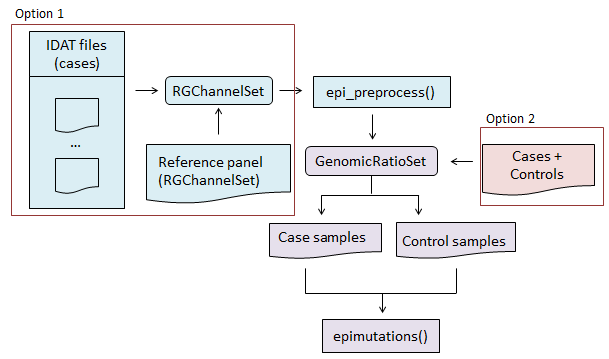

Figure 2: Allowed data formats, normalization and input types

# 3 Datasets

The package contains 3 example datasets adapted from [Gene Expression Omnibus (GEO)](https://www.ncbi.nlm.nih.gov/geo/):

- 1. 4 case samples IDAT files [(GEO: GSE131350)](https://www.ncbi.nlm.nih.gov/geo/query/acc.cgi?acc=GSE131350)
- 2. `reference_panel`: a `RGChannelSet` class object containing 22 healthy individuals [(GEO: GSE127824)](https://www.ncbi.nlm.nih.gov/geo/query/acc.cgi?acc=GSE12782)
- 3. `methy`: a `GenomicRatioSet` object which includes 49 controls [(GEO: GSE104812)](https://www.ncbi.nlm.nih.gov/geo/query/acc.cgi?acc=GSE104812) and 3 cases [(GEO: GSE97362)](https://www.ncbi.nlm.nih.gov/geo/query/acc.cgi).

We also included a dataset specifying the 40,408 candidate regions in Illumina 450K array which could be epimutations (see section 3.3).

We created the `epimutacionsData` package in `ExperimentHub`. It contains the reference panel, methy and the candidate epimutations datasets. The package includes the IDAT files as external data. To access the datasets we need to install the packages by running the following commands:

```r
if (!requireNamespace("BiocManager", quietly = TRUE))
    install.packages("BiocManager")

BiocManager::install("ExperimentHub")
```

```r
devtools::install_github("LeireAbarrategui/epimutacionsData")
```

Then, we need to load the package and create an `ExperimentHub` object:

```r
library(ExperimentHub)
eh <- ExperimentHub()
```

```r
query(eh, c("epimutacionsData"))
```

```
ExperimentHub with 3 records
# snapshotDate(): 2021-09-24
# $dataprovider: GEO, Illumina 450k array
# $species: Homo sapiens
# $rdataclass: RGChannelSet, GenomicRatioSet, GRanges
# additional mcols(): taxonomyid, genome, description, coordinate_1_based,
#   maintainer, rdatadateadded, preparerclass, tags, rdatapath, sourceurl,
#   sourcetype
# retrieve records with, e.g., 'object[["EH6690"]]'

           title
  EH6690 | Control and case samples
  EH6691 | Reference panel
  EH6692 | Candidate epimutations
```

## 3.1 IDAT files and reference panel

IDAT files directory in `epimutacionsData` package:

```r
baseDir <- system.file("extdata", package = "epimutacionsData")
```

The reference panel can be found in `EH6691` record of the `eh` object:

```r
reference_panel <- eh[["EH6691"]]
```

## 3.2 Methy

The `methy` is stored in `EH6690` record:

```r
methy <- eh[["EH6690"]]
```

## 3.3 Candidate regions

In Illumina 450K array, probes are unequally distributed along the genome, limiting the number of regions that can fulfil the requirements to be considered an epimutation. Thus, we have computed a dataset containing all the regions that could be candidates to become an epimutation.

We used the clustering approach from bumphunter to define the candidate epimutations. We defined a primary dataset with all the CpGs from the Illumina 450K array. Then, we run bumphunter and selected those regions with at least 3 CpGs and a maximum distance of 1kb between them. As a result, we found 40,408 candidate epimutations. The function `epimutation()` filters the identified epimutations using these candidate regions.

The following is the code used to identify the candidate epimutations in Illumina 450K array:

```r
library(minfi)
# Regions 450K
library(IlluminaHumanMethylation450kanno.ilmn12.hg19)
data(Locations)

### Select CpGs (names starting by cg) in autosomic chromosomes
locs.450 <- subset(Locations, grepl("^cg", rownames(Locations)) & chr %in% paste0("chr", 1:22))
locs.450GR <- makeGRangesFromDataFrame(locs.450, start.field = "pos", end.field = "pos", strand = "*")
locs.450GR <- sort(locs.450GR)
mat <- matrix(0, nrow = length(locs.450GR), ncol = 2,
              dimnames = list(names(locs.450GR), c("A", "B")))

## Set sample B to all 1
mat[, 2] <- 1

## Define model matrix
pheno <- data.frame(var = c(0, 1))
model <- model.matrix(~ var, pheno)

## Run bumphunter
bumps <- bumphunter(mat, design = model, pos = start(locs.450GR),
                    chr = as.character(seqnames(locs.450GR)),
                    cutoff = 0.05)$table
bumps.fil <- subset(bumps, L >= 3)
```

The candidate regions can be found in `EH6692` record of the `eh` object:

```r
candRegsGR <- eh[["EH6692"]]
```